# Assignment 7: PCoA & nMDS

Luke Ghallahorne

2024-03-06

```r
library(mvabund) # examine spider dataset using ?spider
library(tidyverse) # ggplot()
library(GGally) # ggpairs()
library(vegan) # vegdist()
library(corrplot) # corrplot()
library(ape) # pcoa()
library(PNWColors) # pnw_palette()
library(dendextend) # color_branches(), color_labels()
library(ggpubr) # ggarrange()
```

# Introduction

These data consist of community abundance for twelve hunting spider species, as well as three environmental variables describing the species’ habitats.

Spider Species:

- *Alopecosa accentuata*
- *Alopecosa cuneata*
- *Alopecosa fabrilis*
- *Arctosa lutetiana*
- *Arctosa perita*
- *Aulonia albimana*
- *Pardosa lugubris*
- *Pardosa monticola*
- *Pardosa nigriceps*
- *Pardosa pullata*
- *Trochosa terricola*
- *Zora spinimana*

Species are abbreviated with the first four letters of the genus name followed by the first four letters of the species name.

Environmental Variables:

- bareSand (yes, no): Is there bare sand in the plot?
- leafLitter (yes, no): Are there fallen leaves and/or twigs on the plot?
- reflection: Numeric variable representing reflection of the soil surface with a cloudless sky. Higher values represent greater reflection.

Using these data, I will assess the questions:

- **Is there an observable pattern in these observations of hunting spider communities (i.e., do the samples cluster)?**
- **Do the environmental variables explain any of those patterns?**

```r
spider <- read.csv("Data/07 spiders.csv", stringsAsFactors = TRUE)
```

The dataset has 28 observations/samples of integer counts for each spider species (n = 12, range 0 to 135). It also includes two factor variables, bareSand and leafLitter, measured as yes/no, and one continuous variable, reflection.

## Pairs Plot 1 [,4:9]

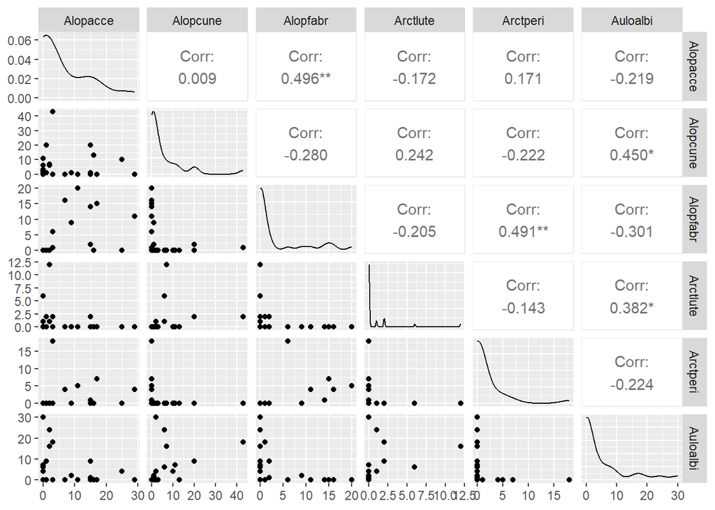

```r
ggpairs(spider[,4:9])
```

## Pairs Plot 2 [,10:15]

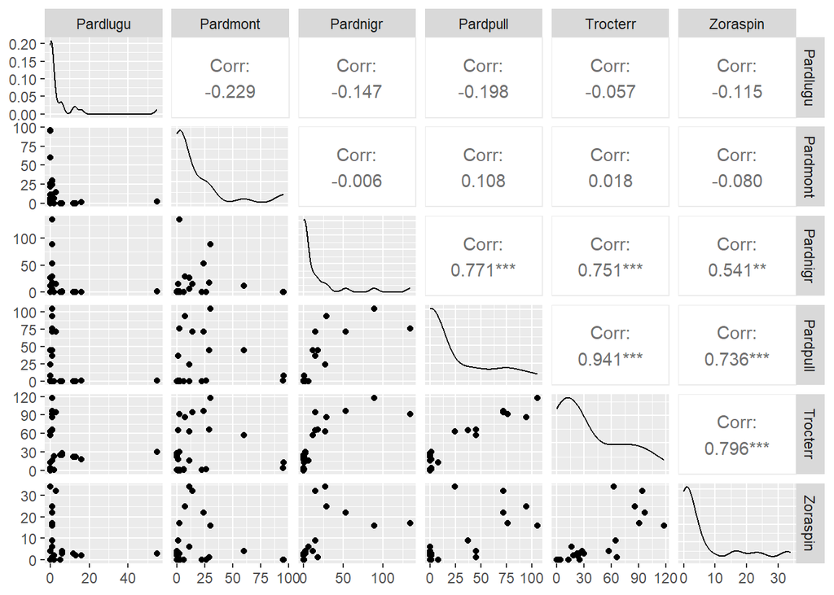

```r
ggpairs(spider[,10:15])
```

## Correlation

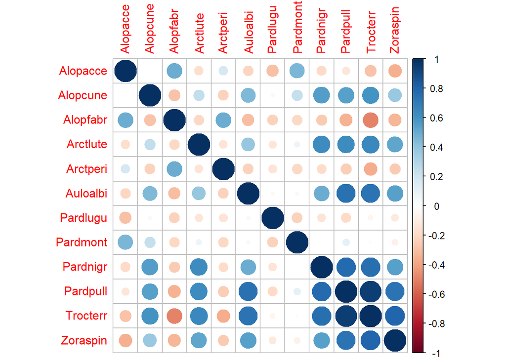

```r
M <- cor(spider[,-c(1:3)])
corrplot(M)
```

The pairs plots above show that these data are not normally distributed. The distribution plots along the diagonals show most counts are in low numbers, with occasional increases in higher numbers, but no variables show the characteristic bell-curve shape of a normal distribution. Moreover, the pairwise plots show a strong tendency toward zeroes and do not form the expected elliptical patterns.

The correlation plot shows that most variables are moderately correlated, not entirely independent (r ~ 0) nor completely overlapping (r ~ +/- 1). Hence, multivariate methods are appropriate for these data.

# Methods

## Ordination

### Principle Coordinates Analysis

I used a Principle Coordinates Analysis (PCoA) for ordination of the data to better visualize any observable patterns in hunting spider communities. After comparing PCoAs with Euclidean, standardized Euclidean, and Bray-Curtis distances/dissimilarities, I chose the Bray-Curtis measures for my final ordination. Bray-Curtis better accounts for data with many repeated zeroes like the spider community data, and preliminary plots showed that samples were grouped more distinctly than with Euclidean measures. The first three Principle Coordinate axes explained 70% of the variation among communities (PCoA1 = 33.4%, PCoA2 = 24.5%, PCoA3 = 11.9%), so I compared those three to assess any patterns.

#### PCoA: Euclidean

```r
# response variable matrix
Y <- as.matrix(spider[,4:15])
# Distance/dissimilarity matrix with Euclidean distances
spider.distEu <- vegdist(Y, method = "euclidean")
# PCoA on distance/dissimilarity matrix
spider.pcoaEu <- pcoa(spider.distEu)
```

```r
# eigenvalues, relative, and broken stick
spider.pcoaEu$values[,1:3]
```

##### Scree Plot

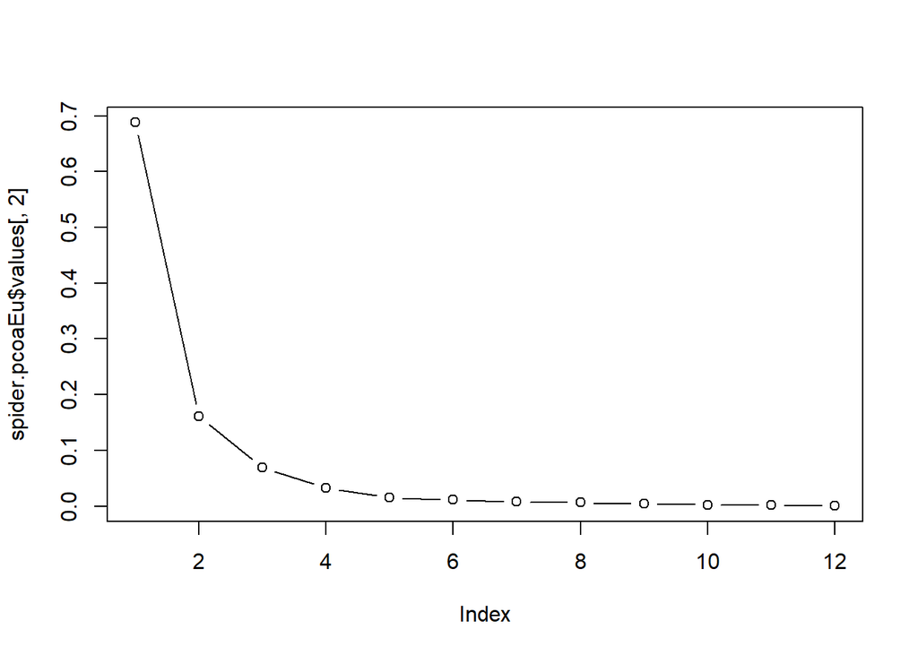

```r
# scree plot of relative eigenvalues
plot(spider.pcoaEu$values[,2], type = "b")
```

The scree plot shows that the majority of variance in the dataset is explained by the first axis, with diminishing returns on variance explained by further axes. This appears promising, but since these are community count data with many zeroes, Euclidean distances over-weigh higher values, meaning that we are likely losing much of the actual variance in communities with this ordination.

```r
spider.pcoaEu$vectors[,1:2]
```

```r
plot.df.pcoaEu <- data.frame(
  axis1 = spider.pcoaEu$vectors[,1],
  axis2 = spider.pcoaEu$vectors[,2],
  bareSand = spider$bareSand,
  leafLitter = spider$leafLitter,
  reflection = spider$reflection)
```

##### Axes 1 & 2

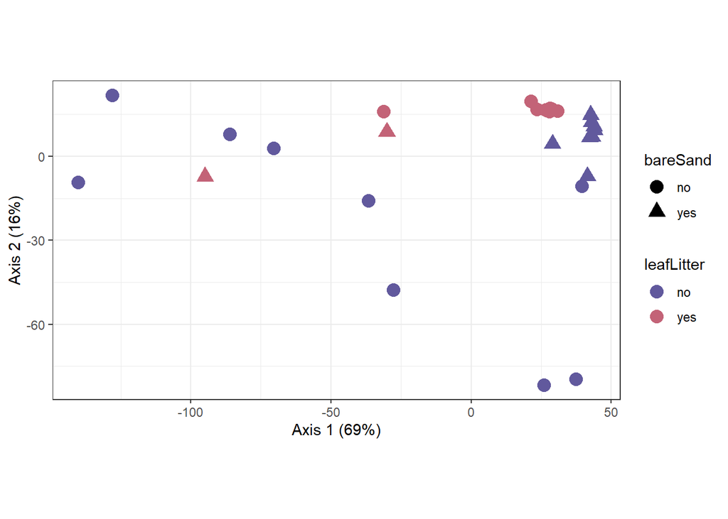

```r
pal1 <- PNWColors::pnw_palette("Sunset2", n = 2)

p1 <- ggplot(data = plot.df.pcoaEu,
             mapping = aes(x = axis1, y = axis2,
                           color = leafLitter, shape = bareSand))+
  geom_point(size = 4) +
  coord_fixed() +
  xlab("Axis 1 (69%)") +
  ylab("Axis 2 (16%)") +
  scale_color_manual(values = pal1) +
  theme_bw()
p1
```

Since the first two axes explained a total of 85% of the variation, I only compared those. Mapping leaf litter as color and bare sand as shape showed little apparent grouping along the axes. Leaf litter (yes) appears concentrated around low values of axis 1 but both positively and negatively, and generally positive in axis 2.

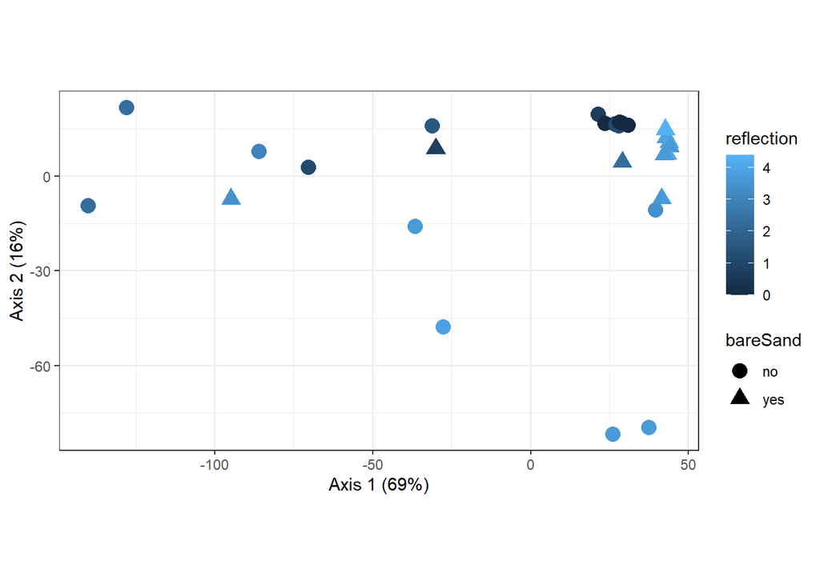

```r
p1.2 <- ggplot(data = plot.df.pcoaEu,
             mapping = aes(x = axis1, y = axis2,
                           color = reflection, shape = bareSand))+
  geom_point(size = 4) +
  coord_fixed() +
  xlab("Axis 1 (69%)") +
  ylab("Axis 2 (16%)") +
  theme_bw()
p1.2
```

Replacing reflection for color, there is a slight trend along Axis 2 of low reflection positive and high reflection negative, but this is broken by the cluster of points at high values of Axis 1. There are no easily discernible patterns for the external variables.

#### PCoA: Standardized Euclidean

```r
# response variable matrix
Y <- as.matrix(spider[,4:15])
# standardize response matrix
Ys <- scale(Y)
# Distance/dissimilarity matrix with Euclidean distances
spider.distEuS <- vegdist(Ys, method = "euclidean")
# PCoA on distance/dissimilarity matrix
spider.pcoaEuS <- pcoa(spider.distEuS)
```

```r
# eigenvalues, relative, and broken stick
spider.pcoaEuS$values[,1:3]
```

##### Scree Plot

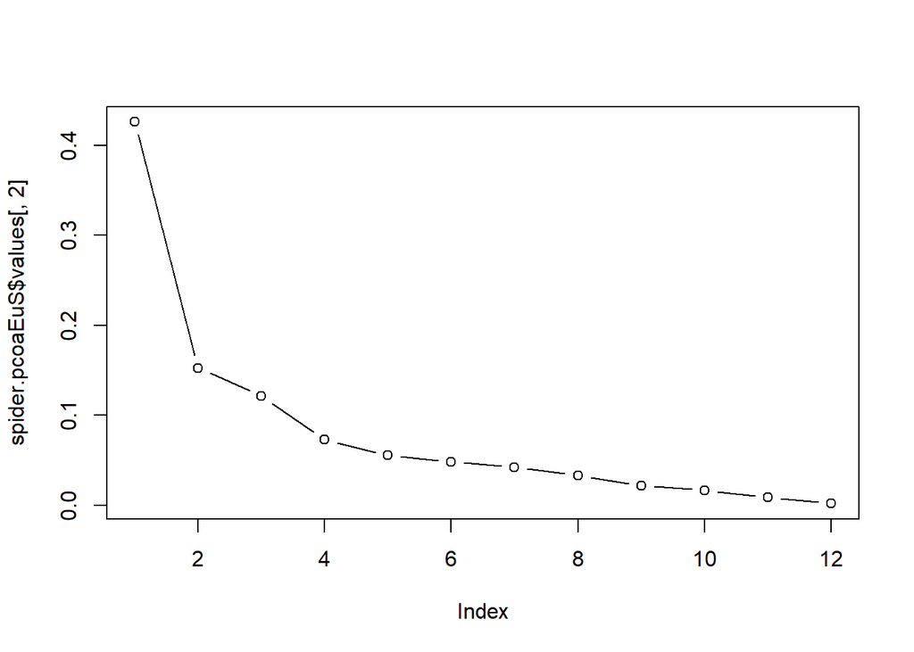

```r
# scree plot of relative eigenvalues
plot(spider.pcoaEuS$values[,2], type = "b")
```

##### Axes 1 & 2

```r
spider.pcoaEuS$vectors[,1:3]
```

```r
plot.df.pcoaEuS <- data.frame(
  axis1 = spider.pcoaEuS$vectors[,1],
  axis2 = spider.pcoaEuS$vectors[,2],
  axis3 = spider.pcoaEuS$vectors[,3],
  bareSand = spider$bareSand,
  leafLitter = spider$leafLitter,
  reflection = spider$reflection)
```

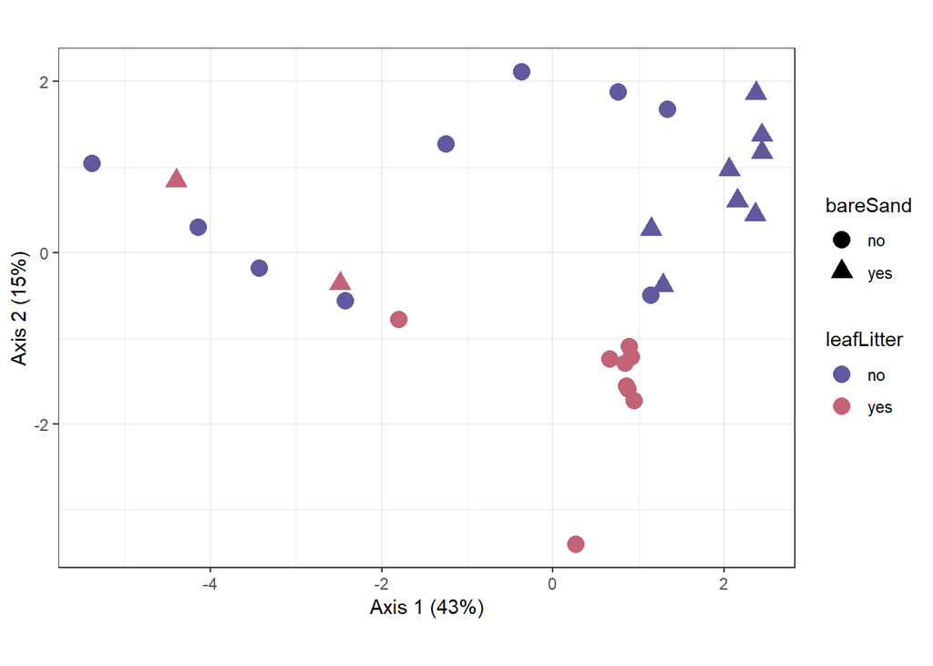

```r
p1 <- ggplot(data = plot.df.pcoaEuS,
             mapping = aes(x = axis1, y = axis2,
                           color = leafLitter, shape = bareSand))+
  geom_point(size = 4) +
  coord_fixed() +
  xlab("Axis 1 (43%)") +
  ylab("Axis 2 (15%)") +
  scale_color_manual(values = pal1) +
  theme_bw()
p1
```

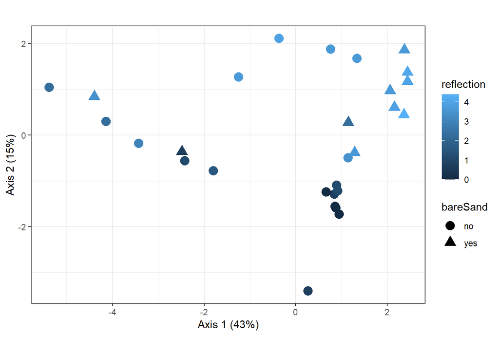

```r
p1.2 <- ggplot(data = plot.df.pcoaEuS,
             mapping = aes(x = axis1, y = axis2,
                           color = reflection, shape = bareSand))+
  geom_point(size = 4) +
  coord_fixed() +
  xlab("Axis 1 (43%)") +
  ylab("Axis 2 (15%)") +
  theme_bw()
p1.2
```

##### Axes 1 & 3

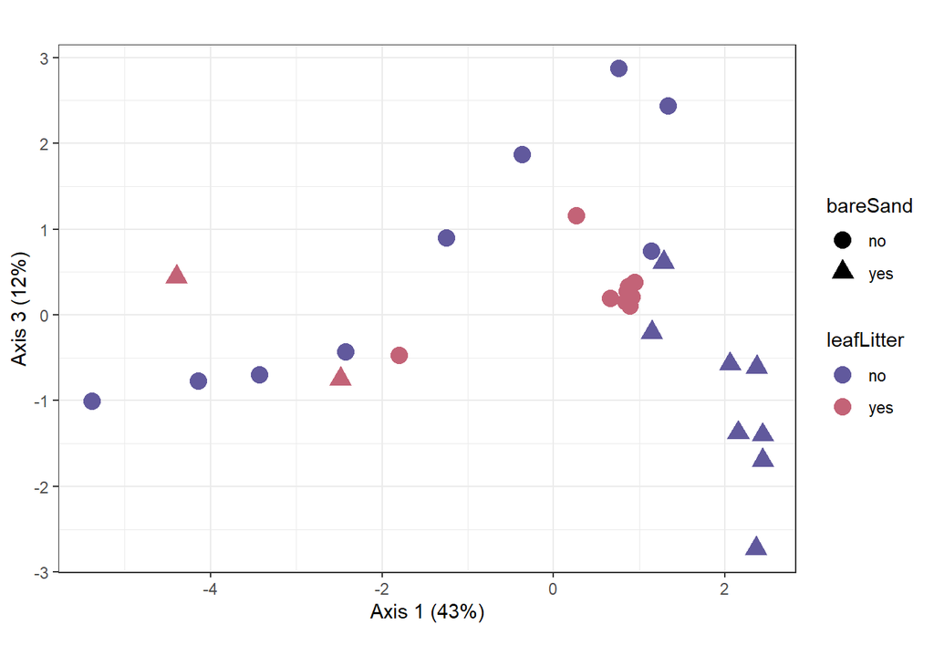

```r
p2 <- ggplot(data = plot.df.pcoaEuS,
             mapping = aes(x = axis1, y = axis3,
                           color = leafLitter, shape = bareSand))+
  geom_point(size = 4) +
  coord_fixed() +
  xlab("Axis 1 (43%)") +
  ylab("Axis 3 (12%)") +
  scale_color_manual(values = pal1) +
  theme_bw()
p2
```

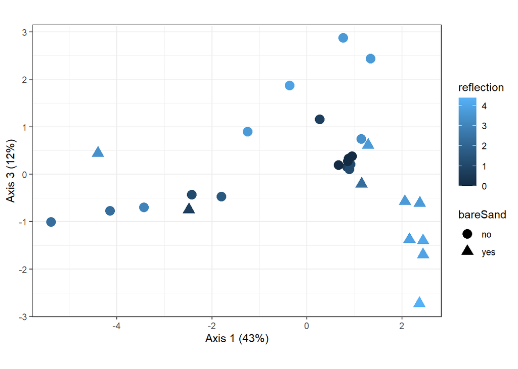

```r
p2.2 <- ggplot(data = plot.df.pcoaEuS,
             mapping = aes(x = axis1, y = axis3,
                           color = reflection, shape = bareSand))+
  geom_point(size = 4) +
  coord_fixed() +
  xlab("Axis 1 (43%)") +
  ylab("Axis 3 (12%)") +
  theme_bw()
p2.2
```